# Assignment 11

# Run an enrichment analysis (rGREAT) of the genes within DMRs vs all genes of chromosome 22

```r
# only genes within the top 5 DMRs
job <- submitGreatJob(gr=dmrGenes, bg=genesChr22, species="hg38")
res <- getEnrichmentTables(job)
```

```
## The default enrichment tables contain no associated genes for the input
## regions.You can set `download_by = 'tsv'` to download the complete
## table,but note only the top 500 regions can be retreived. See the
## following link:
##
## https://great-help.atlassian.net/wiki/spaces/GREAT/pages/655401/Export#Export-GlobalExport
##
## or you can try the local GREAT analysis with the function `great()`.
```

```r
names(res)
```

```
## [1] "GO Molecular Function" "GO Biological Process" "GO Cellular Component"
```

```r
bp <- res$`GO Biological Process`
head(bp)
```

```
##           ID                                                      name
## 1 GO:0098742 cell-cell adhesion via plasma-membrane adhesion molecules
## 2 GO:0000959                       mitochondrial RNA metabolic process
## 3 GO:0000963                              mitochondrial RNA processing
## 4 GO:0002097                             tRNA wobble base modification
## 5 GO:0002098                          tRNA wobble uridine modification
## 6 GO:0002143                   tRNA wobble position uridine thiolation
##   Hyper_Total_Regions Hyper_Expected Hyper_Foreground_Region_Hits
## 1                  23     0.07759784                            3
## 2                   4     0.01349528                            2
## 3                   4     0.01349528                            2
## 4                   4     0.01349528                            2
## 5                   4     0.01349528                            2
## 6                   4     0.01349528                            2
##   Hyper_Fold_Enrichment Hyper_Region_Set_Coverage Hyper_Term_Region_Coverage
```

[output cut: 20 more lines]

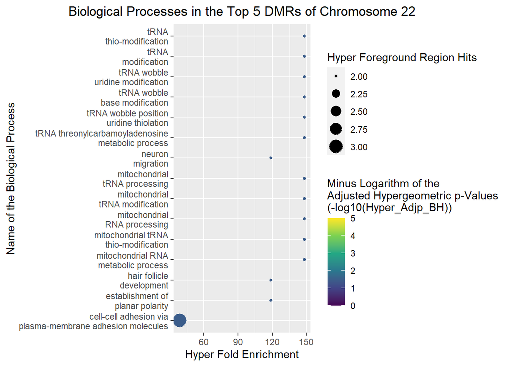

```r
ggplot(head(bp,15), aes(Hyper_Fold_Enrichment, reorder(breakStrings(name, 10, "\n"), Hyper_Adjp_BH), size=Hyper_Foreground_Region_Hits, color=-log10(Hyper_Adjp_BH))) + geom_point() + scale_color_viridis_c(limits = c(0, 5)) + labs(title = "Biological Processes in the Top 5 DMRs of Chromosome 22", x = "Hyper Fold Enrichment", y = "Name of the Biological Process", colour = "Minus Logarithm of the \nAdjusted Hypergeometric p-Values \n(-log10(Hyper_Adjp_BH))", size = "Hyper Foreground Region Hits") + theme(plot.title = element_text(hjust = 0.5))
```

```r
# all genes within DMRs
genesDmr_all <- unlist(tstrsplit(dmrRangesGenes$overlapping.genes, split=", "))
genesDmr_all <- genesDmr_all[!is.na(genesDmr_all)]
dmrGenes_all <- genesChr22[genesChr22$gene_name %in% genesDmr_all]
job <- submitGreatJob(gr=dmrGenes_all, bg=genesChr22, species="hg38")
```

```
## Don't make too frequent requests. The time break is 60s.
## Please wait for 44s for the next request.
## The time break can be set by `request_interval` argument.
```

```r
res <- getEnrichmentTables(job)
```

```
## The default enrichment tables contain no associated genes for the input
## regions.You can set `download_by = 'tsv'` to download the complete
## table,but note only the top 500 regions can be retreived. See the
## following link:
##
## https://great-help.atlassian.net/wiki/spaces/GREAT/pages/655401/Export#Export-GlobalExport
##
## or you can try the local GREAT analysis with the function `great()`.
```

```r
names(res)
```

```
## [1] "GO Molecular Function" "GO Biological Process" "GO Cellular Component"
```

```r
bp <- res$`GO Biological Process`
head(bp)
```

```
##           ID                             name Hyper_Total_Regions
## 1 GO:0065007            biological regulation                1116
## 2 GO:0065008 regulation of biological quality                 424
## 3 GO:0050789 regulation of biological process                1088
## 4 GO:0050794   regulation of cellular process                1077
## 5 GO:0010646 regulation of cell communication                 415
## 6 GO:0023051          regulation of signaling                 416
##   Hyper_Expected Hyper_Foreground_Region_Hits Hyper_Fold_Enrichment
## 1       400.6154                          446              1.113287
## 2       152.2051                          198              1.300876
## 3       390.5641                          432              1.106092
## 4       386.6154                          428              1.107043
## 5       148.9744                          188              1.261962
## 6       149.3333                          188              1.258929
##   Hyper_Region_Set_Coverage Hyper_Term_Region_Coverage
```

[output cut: 20 more lines]

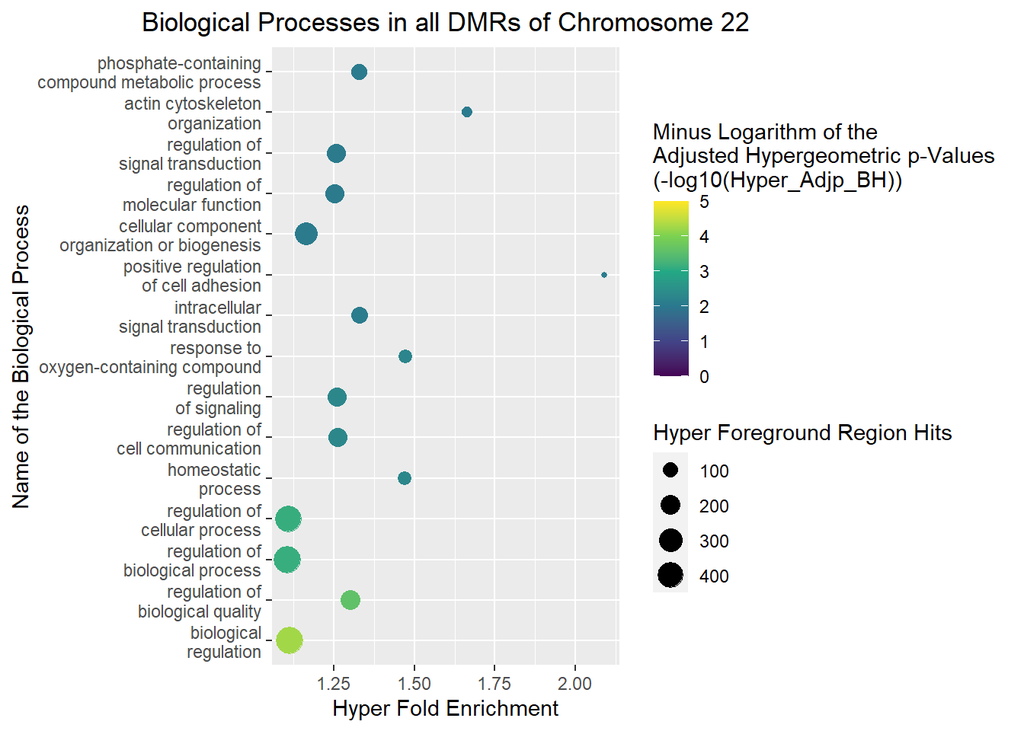

```r
ggplot(head(bp,15), aes(Hyper_Fold_Enrichment, reorder(breakStrings(name, 10, "\n"), Hyper_Adjp_BH), size=Hyper_Foreground_Region_Hits, color=-log10(Hyper_Adjp_BH))) + geom_point() + scale_color_viridis_c(limits = c(0, 5)) + labs(title = "Biological Processes in all DMRs of Chromosome 22", x = "Hyper Fold Enrichment", y = "Name of the Biological Process", colour = "Minus Logarithm of the \nAdjusted Hypergeometric p-Values \n(-log10(Hyper_Adjp_BH))", size = "Hyper Foreground Region Hits") + theme(plot.title = element_text(hjust = 0.5))
```

## Describe what your enrichment analysis is testing exactly & describe the results

I have performed two different enrichment analyses testing two slightly different things. In both cases I get a table showing for each biological function how much it is represented in the selected regions compared to all genes of chromosome 22, and how significant this difference is, and a plot, to visualize the results. The most important columns of the table basically tell for each biological process how many regions you can identify in those DMRs with that function, how many you would normally expect just by chance in chromosome 22, the ratio between them, and the p-value (the raw one and the adjusted one). This is more or less also what the plot represents. For each biological function (represented on the y-axis), we can see the hyper fold enrichment on the x-axis, which is the the proportion of genes related to that function compared to the rest of the genes (in the selected set of DMRs). In addition, the size of the dot represents whether this is a lot or not (compared to chromosome 22), and the color represents whether these findings are significant (yellow stands for a lower p-value (more significant), whereas darker colours represent higher p-values). If we assume a significance threshold of 5%, then -log10(0.05) = 1.3, therefore all the dots that tend to be from dark green to yellow are significant, whereas the dots that are blue/ dark blue/ dark violet are not significant.

Secondly, I have tested all DMRs vs all genes of chromosome 22. There we the hyperfold enrichment for the different biological functions is lower compared to the previous analysis, but the differences we catch are much more evident and significant. This is probably due to the fact that we are looking at a broader set of DMRs, while always comparing with the genes in chromosome 22. Some of the listed functions are quite vague, but others that are more clear are very interesting, e.g.”cellular component organization or biogenesis”. Some of these functions are known to be changed in cancer cells.

Overall, this analysis shows that some biological processes that are important/ changed in cancer development seem to be associated with DNA methylation regulation.